# Tarea 2

# Tarea 2: Frequentist Inference

**CC6104: Statistical Thinking**

#### **Integrantes :**

- Ignacio Albornoz
- Alejandra Toro

#### **Cuerpo Docente:**

- Profesor: Felipe Bravo M.
- Auxiliares: Martín Paredes, Benjamín Farías
- Ayudantes: Renzo Zanca, Kevin Iturra, Emilio Díaz, Scarleth Betancurt

#### **Fecha límite de entrega:**

### **Índice:**

1. Objetivo
2. Instrucciones
3. Referencias
4. Elaboración de Código

### **Objetivo**

Bienvenid@s a la segunda tarea del curso Statistical Thinking. Esta tarea tiene como objetivo evaluar los contenidos teóricos de la segunda parte del curso, los cuales se enfocan principalmente en inferencia estadística, diseño de experimentos y test de hipótesis. Si aún no han visto las clases, se recomienda visitar los enlaces de las referencias.

La tarea consta de una parte teórica que busca evaluar conceptos vistos en clases. Seguido por una parte práctica con el fin de introducirlos a la programación en R enfocada en el análisis estadístico de datos.

### **Instrucciones:**

- La tarea se realiza en grupos de **máximo 2 personas**. Pero no existe problema si usted desea hacerla de forma individual.
- La entrega es a través de u-cursos a más tardar el día estipulado en la misma plataforma. A las tareas atrasadas se les descontará un punto por día.
- El formato de entrega es este mismo **Rmarkdown** y un **html** con la tarea desarrollada. Por favor compruebe que todas las celdas han sido ejecutadas en el archivo html.
- Al momento de la revisión tu código será ejecutado. Por favor verifica que tu entrega no tenga errores de compilación.
- No serán revisadas tareas desarrolladas en Python.
- Está **PROHIBIDO** la copia o compartir las respuestas entre integrantes de diferentes grupos.
- Pueden realizar consultas de la tarea a través de U-cursos y/o del canal de Discord del curso.

### **Referencias:**

Slides de las clases:

- [Introduction to Statistical Inference](https://github.com/dccuchile/CC6104/blob/master/slides/ST-inference.pdf)
- [Design of Experiments & Hypothesis Testing](https://github.com/dccuchile/CC6104/blob/master/slides/ST-hypothesis.pdf)

Enlaces a videos de las clases:

- Introduction to Statistical Inference: [video1](https://youtu.be/A0BAhO9_RSI) [video2](https://youtu.be/6Io555e2stM) [video3](https://youtu.be/2-Q2f6zmTns) [video4](https://youtu.be/Hp2A5EJoXbk) [video5](https://youtu.be/M0Ag4bww7Q0) [video6](https://youtu.be/K7khgecup3I) [video7](https://youtu.be/uZ126Lh3L-k) [video8](https://youtu.be/kHSPx99nJ7g)
- Design of Experiments & Hypothesis Testing: [video1](https://youtu.be/3MueyHnNNig) [video2](https://youtu.be/JuyIrya23E0) [video3](https://youtu.be/OXTyG6DIvK4) [video4](https://youtu.be/95QeSwrNoLI) [video5](https://youtu.be/ZCr3WCdc-54) [video6](https://youtu.be/T6ZR0KoKhBQ)

Documentación:

- [Boostrap en r](https://www.datacamp.com/community/tutorials/bootstrap-r)
- [ggplot2](https://ggplot2.tidyverse.org/)

# Elaboración de Código

En la siguiente sección deberá resolver cada uno de los experimentos computacionales a través de la programación en R. Para esto se le aconseja que cree funciones en R, ya que le facilitará la ejecución de gran parte de lo solicitado.

Elimine `eval=FALSE` para ejecutar las celdas.

### Pregunta 1: Estimadores.

- Considere una serie de variables aleatorias $X_i$ que siguen una distribución de Bernoulli de parámetro $p=0.5$ y un estimador de $p$ dado por $\hat{p}_{n, \sigma} = \epsilon_{\sigma} + \frac{1}{n} \displaystyle{\sum_{i=1}^{n}}X_{i}$ donde $\epsilon_{\sigma} \sim \mathcal{N}(0,\sigma)$. Para $\sigma = 0, 1, 2, 4$ grafique el valor de $\hat{p}_{n, \sigma}$ y comparelo con el valor verdadero. Calcule el sesgo del estimador para cada valor de $\sigma$.

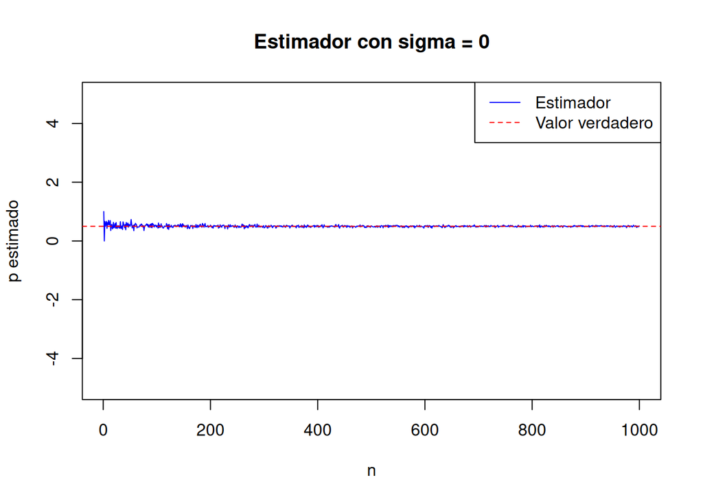

```r
# sigma = 0
sigma = 0
cte <- rep(0.5, 1000)
x <- 1:1000
data <- c()

for (n in x) {
  X <- rbinom(n, size = 1, prob = 0.5)  # Simular n variables aleatorias de Bernoulli
  p_estimado <- (1 / n) * sum(X)  # Calcular p estimado
  epsilon_sigma <- rnorm(1, mean = 0, sd = sigma)  # Agregar el ruido una sola vez
  p_estimado <- p_estimado + epsilon_sigma
  data <- c(data, p_estimado)
}

plot(x, data, type = "l", col = "blue", ylim = c(-5, 5), main = "Estimador con sigma = 0", ylab = "p estimado", xlab = "n")
abline(h = 0.5, col = "red", lty = 2)  # Valor verdadero de p
legend("topright", legend = c("Estimador", "Valor verdadero"), col = c("blue", "red"), lty = c(1, 2))
```

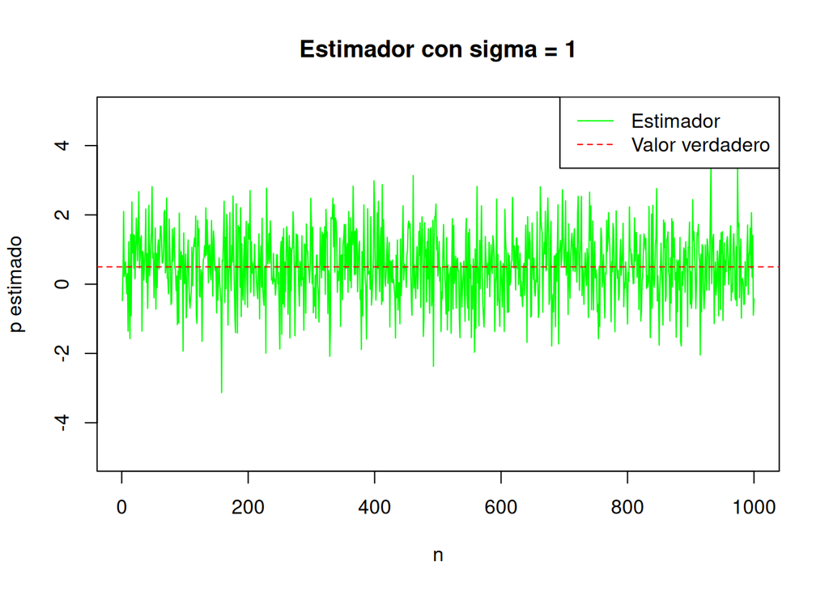

```r
# sigma = 1
sigma = 1
cte <- rep(0.5, 1000)
x <- 1:1000
data <- c()

for (n in x) {
  X <- rbinom(n, size = 1, prob = 0.5)  # Simular n variables aleatorias de Bernoulli
  p_estimado <- (1 / n) * sum(X)  # Calcular p estimado
  epsilon_sigma <- rnorm(1, mean = 0, sd = sigma)  # Agregar el ruido una sola vez
  p_estimado <- p_estimado + epsilon_sigma
  data <- c(data, p_estimado)
}

plot(x, data, type = "l", col = "green", ylim = c(-5, 5), main = "Estimador con sigma = 1", ylab = "p estimado", xlab = "n")
abline(h = 0.5, col = "red", lty = 2)  # Valor verdadero de p
legend("topright", legend = c("Estimador", "Valor verdadero"), col = c("green", "red"), lty = c(1, 2))
```

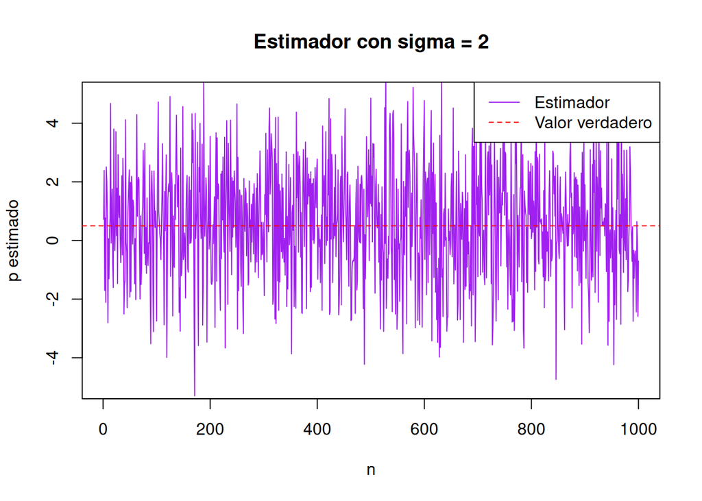

```r
# sigma = 2
sigma = 2
cte <- rep(0.5, 1000)
x <- 1:1000
data <- c()

for (n in x) {
  X <- rbinom(n, size = 1, prob = 0.5)  # Simular n variables aleatorias de Bernoulli
  p_estimado <- (1 / n) * sum(X)  # Calcular p estimado
  epsilon_sigma <- rnorm(1, mean = 0, sd = sigma)  # Agregar el ruido una sola vez
  p_estimado <- p_estimado + epsilon_sigma
  data <- c(data, p_estimado)
}

plot(x, data, type = "l", col = "purple", ylim = c(-5, 5), main = "Estimador con sigma = 2", ylab = "p estimado", xlab = "n")
abline(h = 0.5, col = "red", lty = 2)  # Valor verdadero de p
legend("topright", legend = c("Estimador", "Valor verdadero"), col = c("purple", "red"), lty = c(1, 2))
```

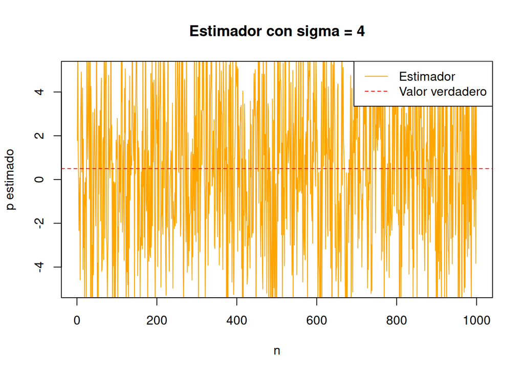

```r
# sigma = 4
sigma = 4
cte <- rep(0.5, 1000)
x <- 1:1000
data <- c()

for (n in x) {
  X <- rbinom(n, size = 1, prob = 0.5)  # Simular n variables aleatorias de Bernoulli
  p_estimado <- (1 / n) * sum(X)  # Calcular p estimado
  epsilon_sigma <- rnorm(1, mean = 0, sd = sigma)  # Agregar el ruido una sola vez
  p_estimado <- p_estimado + epsilon_sigma
  data <- c(data, p_estimado)
}

plot(x, data, type = "l", col = "orange", ylim = c(-5, 5), main = "Estimador con sigma = 4", ylab = "p estimado", xlab = "n")
abline(h = 0.5, col = "red", lty = 2)  # Valor verdadero de p
legend("topright", legend = c("Estimador", "Valor verdadero"), col = c("orange", "red"), lty = c(1, 2))
```

- ¿Qué puede decir del sesgo de los estimadores $\hat{p}_{n,\sigma}$?¿Son los estimadores con menos sesgo más precisos? Justifique.

### Pregunta 2: Intervalo de Confidencia

En las preguntas 2, 3 y 4 deberá trabajar con el dataset `diabetes_prediction_dataset`.

```r
datos <- read.csv("diabetes_prediction_dataset.csv", header = TRUE)
head(datos)
```

|  | gender | age | hypertension | heart_disease | smoking_history | bmi | HbA1c_level | blood_glucose_level | diabetes |
| --- | --- | --- | --- | --- | --- | --- | --- | --- | --- |
| 1 | Female | 80 | 0 | 1 | never | 25.19 | 6.6 | 140 | 0 |
| 2 | Female | 54 | 0 | 0 | No Info | 27.32 | 6.6 | 80 | 0 |
| 3 | Male | 28 | 0 | 0 | never | 27.32 | 5.7 | 158 | 0 |
| 4 | Female | 36 | 0 | 0 | current | 23.45 | 5.0 | 155 | 0 |
| 5 | Male | 76 | 1 | 1 | current | 20.14 | 4.8 | 155 | 0 |
| 6 | Female | 20 | 0 | 0 | never | 27.32 | 6.6 | 85 | 0 |

Una forma de estimar la distribución de la media de una población es a través de la realización de la `sampling distribution` de una distribución cualquiera. El valor obtenido en cada sampling distribution nos entrega un estimador de la media que posee una determinada distribución de la población. Sabiendo esto, calcule la `sampling distribution` de las columnas `bmi` y `blood_glucose_level`, obteniendo el intervalo de confianza de $95\%$ para cada una de las medias obtenidas desde la distribución. Para realizar este experimento considere los siguientes puntos:

- Obtener las medias y desviaciones estándar de la población real.
- Realizar una `sampling distribution` con un tamaño de muestra igual a $100$. Repita la obtención de la media un número elevado de veces (recomendación $5000$ veces).
- Calcular el intervalo de confianza para cada uno de las medias obtenidas en las iteraciones.
- De acuerdo a los valores obtenidos (medias e intervalos de confianza), grafique cada una de las medias obtenidas en conjunto a sus intervalos de confianza. Aquí debe notar que, si el intervalo de confianza contiene a la media de la población, este se considerará como parte del intervalo de confianza del $95\%$, haga un conteo de cuantos valores están contenidos en este intervalo. Para graficar los intervalos deconfianza puede ser útil utilizar forest plot.
- Compare las estimaciones para `bmi` y `blood_glucose_level` y señale que diferencias y similitudes encuentra entre estas (en cuanto a la calidad de la estimación, no los valores obtenidos). De una explicación de por qué cree que se dan las similitudes/diferencias.

**Hints**:

- Para comparar comparar las 2 estimaciones puede ser útil normalizar `bmi` y `blood_glucose_level` a una misma escala.
- Para realizar la `sampling distribution` podría serle útil el comando `sample()`.
- Puede ser útil generar un dataframe para graficar con ggplot2.

**Respuesta:**

```r
# Definimos tamaños de muestreo
tamano_muestra = 100
n_muestras = 100

# Inicializamos estructuras necesarias
list_mean_bmi = vector()
list_interval_bmi = list()  # Lista anidada para guardar los intervalos como pares (lower, upper)
sucess_bmi = 0

list_mean_bgl = vector()
list_interval_bgl = list()  # Lista anidada para guardar los intervalos como pares (lower, upper)
sucess_bgl = 0

# Eliminar valores NA de las columnas relevantes
datos_bmi <- na.omit(datos$bmi)
datos_bgl <- na.omit(datos$blood_glucose_level)

# Normalizamos las variables a una misma escala (z-score normalization)
datos_bmi_norm <- scale(datos_bmi)
datos_bgl_norm <- scale(datos_bgl)

# Obtenemos la media y desviación estándar de la población real
media_bmi <- mean(datos_bmi_norm)
desviacion_bmi <- sd(datos_bmi_norm)

media_bgl <- mean(datos_bgl_norm)
desviacion_bgl <- sd(datos_bgl_norm)

# Sampling distribution, calculo del intervalo de confianza y proporción.
set.seed(123) # Para reproducibilidad
for (i in 1:n_muestras) {

  # Muestreo y cálculo para BMI
  muestra_bmi <- sample(datos_bmi_norm, tamano_muestra, replace = FALSE)
  media_muestra_bmi <- mean(muestra_bmi)
  error_bmi <- qt(0.975, df = tamano_muestra - 1) * (sd(muestra_bmi) / sqrt(tamano_muestra))
  intervalo_bmi <- c(media_muestra_bmi - error_bmi, media_muestra_bmi + error_bmi)  # (lower, upper)

  # Verificar si la media de la población cae en el intervalo
  if (media_bmi >= intervalo_bmi[1] && media_bmi <= intervalo_bmi[2]) {
    sucess_bmi <- sucess_bmi + 1
  }

  # Guardar resultados
  list_mean_bmi <- c(list_mean_bmi, media_muestra_bmi)
  list_interval_bmi[[i]] <- intervalo_bmi  # Guardamos el intervalo completo como par

  # Muestreo y cálculo para blood_glucose_level
  muestra_bgl <- sample(datos_bgl_norm, tamano_muestra, replace = FALSE)
  media_muestra_bgl <- mean(muestra_bgl)
  error_bgl <- qt(0.975, df = tamano_muestra - 1) * (sd(muestra_bgl) / sqrt(tamano_muestra))
  intervalo_bgl <- c(media_muestra_bgl - error_bgl, media_muestra_bgl + error_bgl)  # (lower, upper)

  # Verificar si la media de la población cae en el intervalo
  if (media_bgl >= intervalo_bgl[1] && media_bgl <= intervalo_bgl[2]) {
    sucess_bgl <- sucess_bgl + 1
  }

  # Guardar resultados
  list_mean_bgl <- c(list_mean_bgl, media_muestra_bgl)
  list_interval_bgl[[i]] <- intervalo_bgl  # Guardamos el intervalo completo como par
}

# Proporción de veces que la media verdadera cae en el intervalo
prop_bmi <- sucess_bmi / n_muestras * 100
prop_bgl <- sucess_bgl / n_muestras * 100

cat("Proporción de intervalos que contienen la media para BMI:", prop_bmi, "%\n")
```

```
## Proporción de intervalos que contienen la media para BMI: 94 %
```

```r
cat("Proporción de intervalos que contienen la media para BGL:", prop_bgl, "%\n")
```

```
## Proporción de intervalos que contienen la media para BGL: 94 %
```

```r
# Generamos dataframes para plotear fácilmente los datos (opcional para ggplot)
df_bmi <- data.frame(
  mean = list_mean_bmi,
  lower = sapply(list_interval_bmi, `[`, 1),  # Límite inferior del intervalo
  upper = sapply(list_interval_bmi, `[`, 2)   # Límite superior del intervalo
)

df_bgl <- data.frame(
  mean = list_mean_bgl,
  lower = sapply(list_interval_bgl, `[`, 1),
  upper = sapply(list_interval_bgl, `[`, 2)
)

cat("Longitud de list_mean_bmi:", length(list_mean_bmi), "\n")
```

```
## Longitud de list_mean_bmi: 100
```

```r
cat("Longitud de list_mean_bgl:", length(list_mean_bgl), "\n")
```

```
## Longitud de list_mean_bgl: 100
```

```r
fig.width=15

fig.height=6
```

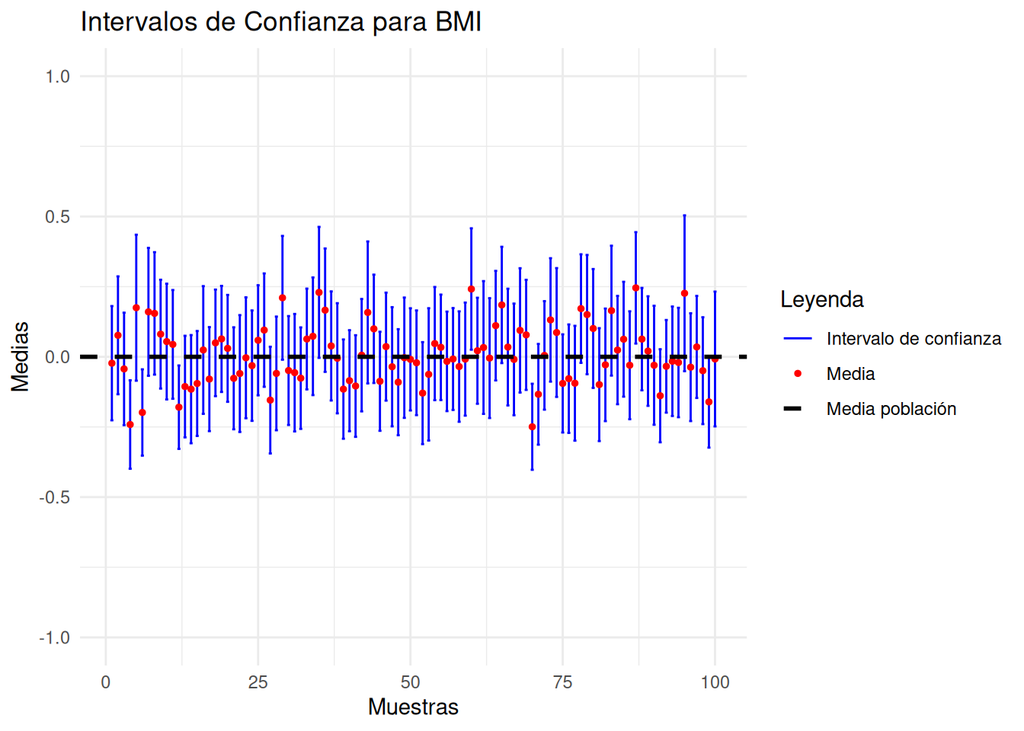

```r
# Plot de Intervalos de confianza

# Plot de Intervalos de confianza para BMI
ggplot(df_bmi, aes(x = 1:nrow(df_bmi), y = mean)) +
  geom_errorbar(aes(ymin = lower, ymax = upper, color = "Intervalo de confianza"), width = 0.5) +  # Intervalo de confianza
  geom_point(aes(color = "Media"), size = 1) +  # Media
  geom_hline(aes(yintercept = media_bmi, color = "Media población"), linetype = "dashed", size = 1) +  # Media de la población
  labs(title = "Intervalos de Confianza para BMI", x = "Muestras", y = "Medias") +
  theme_minimal() +
  ylim(-1, 1) +  # Ajustamos el eje y
  scale_color_manual(name = "Leyenda", values = c("Intervalo de confianza" = "blue", "Media" = "red", "Media población" = "black"))
```

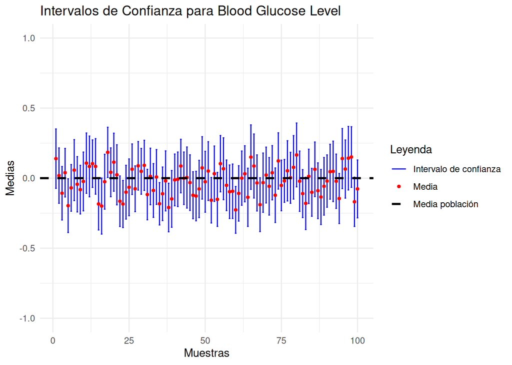

```r
# Plot de Intervalos de confianza

# Plot de Intervalos de confianza para Blood Glucose Level (BGL)
ggplot(df_bgl, aes(x = 1:nrow(df_bgl), y = mean)) +
  geom_errorbar(aes(ymin = lower, ymax = upper, color = "Intervalo de confianza"), width = 0.5) +  # Intervalo de confianza
  geom_point(aes(color = "Media"), size = 1) +  # Media
  geom_hline(aes(yintercept = media_bgl, color = "Media población"), linetype = "dashed", size = 1) +  # Media de la población
  labs(title = "Intervalos de Confianza para Blood Glucose Level", x = "Muestras", y = "Medias") +
  theme_minimal() +
  ylim(-1, 1) +  # Ajustamos el eje y
  scale_color_manual(name = "Leyenda", values = c("Intervalo de confianza" = "blue", "Media" = "red", "Media población" = "black"))
```

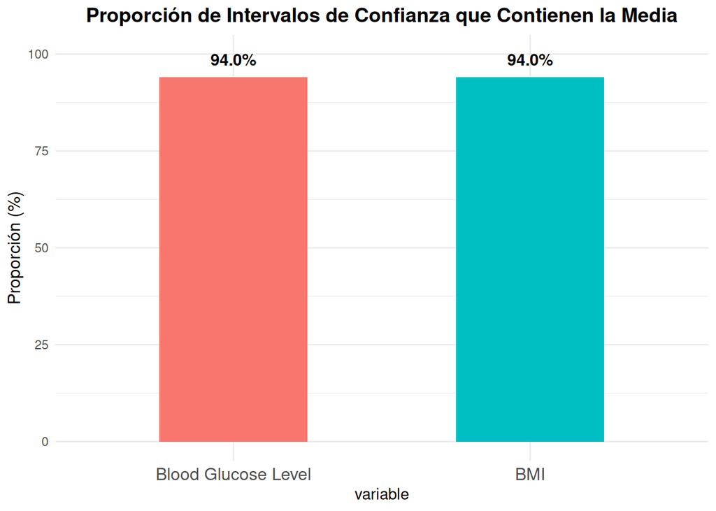

```r
# Plot de proporción de CI que contienen la media

df_proporciones <- data.frame(
  variable = c("BMI", "Blood Glucose Level"),
  proporciones = c(prop_bmi, prop_bgl)
)

ggplot(df_proporciones, aes(x = variable, y = proporciones, fill = variable)) +
  geom_bar(stat = "identity", width = 0.5) +
  geom_text(aes(label = sprintf("%.1f%%", proporciones)),
            vjust = -1, size = 4, fontface = "bold") +  # Ajustar posición y formato del texto
  labs(title = "Proporción de Intervalos de Confianza que Contienen la Media",
       y = "Proporción (%)") +
  ylim(0, 100) +
  theme_minimal() +
  theme(legend.position = "none",
        plot.title = element_text(hjust = 0.5, size = 14, face = "bold"),
        axis.title.y = element_text(size = 12),
        axis.text.x = element_text(size = 12))
```

```r
# Cálculo de los largos promedio de los intervalos de confianza
longitud_intervalos_bmi <- sapply(list_interval_bmi, function(x) x[2] - x[1])
longitud_intervalos_bgl <- sapply(list_interval_bgl, function(x) x[2] - x[1])

largo_promedio_bmi <- mean(longitud_intervalos_bmi)
largo_promedio_bgl <- mean(longitud_intervalos_bgl)

cat("Largo promedio de los intervalos de confianza para BMI:", largo_promedio_bmi, "\n")
```

```
## Largo promedio de los intervalos de confianza para BMI: 0.3975549
```

```r
cat("Largo promedio de los intervalos de confianza para Blood Glucose Level:", largo_promedio_bgl, "\n")
```

```
## Largo promedio de los intervalos de confianza para Blood Glucose Level: 0.3891668
```

```r
# Cálculo de la desviación promedio de las medias respecto a la media poblacional (0)
desviacion_media_bmi <- mean(abs(list_mean_bmi))
desviacion_media_bgl <- mean(abs(list_mean_bgl))

cat("Desviación promedio de las medias respecto a la media poblacional (BMI):", desviacion_media_bmi, "\n")
```

```
## Desviación promedio de las medias respecto a la media poblacional (BMI): 0.08295841
```

```r
cat("Desviación promedio de las medias respecto a la media poblacional (Blood Glucose Level):", desviacion_media_bgl, "\n")
```

```
## Desviación promedio de las medias respecto a la media poblacional (Blood Glucose Level): 0.0860557
```

```r
error_estandar_bmi <- sd(list_mean_bmi)
error_estandar_bgl <- sd(list_mean_bgl)

cat("Error estándar de las medias para BMI:", error_estandar_bmi, "\n")
```

```
## Error estándar de las medias para BMI: 0.1056977
```

```r
cat("Error estándar de las medias para Blood Glucose Level:", error_estandar_bgl, "\n")
```

```
## Error estándar de las medias para Blood Glucose Level: 0.1011579
```

```r
rmse_bmi <- sqrt(mean((list_mean_bmi - media_bmi)^2))
rmse_bgl <- sqrt(mean((list_mean_bgl - media_bgl)^2))

cat("RMSE para BMI:", rmse_bmi, "\n")
```

```
## RMSE para BMI: 0.1054265
```

```r
cat("RMSE para Blood Glucose Level:", rmse_bgl, "\n")
```

```
## RMSE para Blood Glucose Level: 0.1032902
```

```r
bias_bmi <- mean(list_mean_bmi) - media_bmi
bias_bgl <- mean(list_mean_bgl) - media_bgl

cat("Sesgo para BMI:", bias_bmi, "\n")
```

```
## Sesgo para BMI: 0.007380066
```

```r
cat("Sesgo para Blood Glucose Level:", bias_bgl, "\n")
```

```
## Sesgo para Blood Glucose Level: -0.02320077
```

> Respuesta

El experimento se centró en estimar la media poblacional de las variables BMI y Blood Glucose Level mediante la creación de una distribución de muestreo y el cálculo de intervalos de confianza del 95%. Para lograrlo, se utilizó el valor crítico de la distribución t de Student (t ≈ 1.984), ya que el tamaño de muestra fue de 100 y no se conocía la desviación estándar poblacional. Este valor crítico permitió calcular los intervalos de confianza para cada una de las 100 muestras obtenidas. Posteriormente, se verificó cuántos de esos intervalos incluían la media poblacional. El 94% de los intervalos para ambas variables contenían la media, lo cual está bastante alineado con el valor teórico esperado del 95%.

Además, los intervalos de confianza varían ligeramente en longitud, lo que indica leves diferencias en la variabilidad de las muestras. Algunos intervalos son más largos que otros, lo que refleja una mayor incertidumbre en ciertas estimaciones específicas. Esta fluctuación leve en los largos de los intervalos sugiere que las muestras con mayor variabilidad intrínseca tienden a generar estimaciones más imprecisas.

Al observar los resultados numéricos, el largo promedio de los intervalos de confianza para BMI es de 0.3976 y para Blood Glucose Level es de 0.3892, lo que indica que la precisión en las estimaciones es similar para ambas variables. Sin embargo, al examinar la desviación promedio de las medias muestrales respecto a la media poblacional, se encuentra que BMI tiene una desviación de 0.0830 mientras que Blood Glucose Level tiene una desviación de 0.0861. Esto muestra que ambas variables presentan medias muestrales que, en promedio, están cerca de la media poblacional, pero la desviación es ligeramente mayor en Blood Glucose Level.

El error estándar de las medias para BMI es de 0.1057 y para Blood Glucose Level es de 0.1012, lo que confirma que la dispersión de las medias muestrales es prácticamente la misma para ambas variables, indicando una precisión comparable en las estimaciones. Los valores del RMSE, que son de 0.1054 para BMI y 0.1033 para Blood Glucose Level, refuerzan la idea de que las estimaciones están, en promedio, bastante cercanas a la media poblacional.

Finalmente, el sesgo para BMI es de 0.0074 y para Blood Glucose Level es de -0.0232, lo que indica que ambas variables tienen estimaciones muestrales cercanas a la media poblacional, aunque Blood Glucose Level presenta un leve sesgo negativo, lo que sugiere una ligera subestimación de la media verdadera.

En conclusión, los resultados muestran que las estimaciones para BMI y Blood Glucose Level son comparables en términos de calidad. Los largos de los intervalos de confianza, las desviaciones de las medias y los errores estándar indican que ambas variables tienen una estimación precisa y estable. Las pequeñas diferencias en el sesgo y el RMSE se deben a la variabilidad intrínseca de los datos, pero en general, las dos variables presentan un comportamiento similar en cuanto a la alta calidad de las estimaciones.

### Pregunta 3: Estimación de Máxima Verosimilitud

El objetivo de esta parte será estimar la media `bmi` mediante MLE. Para responder la pregunta realice los siguientes puntos:

- Grafique el histograma de `bmi` y obtenga la media y varianza de los datos.
- Calcule el valor teórico del estimador de máxima verosimilitud $\hat{\mu}$ para la media, asumiendo una distribución normal y fijando $\sigma^2$ en la varianza muestral.

$$loglike(\mu) = -\frac{n}{2}\ln{2\pi}-n\log\sigma
-\frac{1}{2\sigma^2}\sum^n_{i=1}(x_i-\mu)^2$$

- Gráfique a traves de un gráfico de calor el rango de valores en que se mueve la solución del problema de likelihood (puede ser útil `persp()` o `filled.contour()`). Considere el histograma de `bmi` y el valor de $\hat{\mu}$ para definir un rango adecuado para la media, y que $\sigma$ está entre 1 y 7.
- Aplique el comando `nlminb()` sobre la función likelihood (o log-likelihood) para encontrar el óptimo de $\mu$ y $\sigma$ computacionalemte.
- Compare el valor dado por `nlminb()` con el resultado teórico y la media muestral, y comente sus resultados.

Cabe señalar que el método de máxima verosimilitud deberá ser programado por usted y **no** podrá utilizar librerías que entreguen el valor directo (por ejemplo la librería MASS).

**Respuesta**

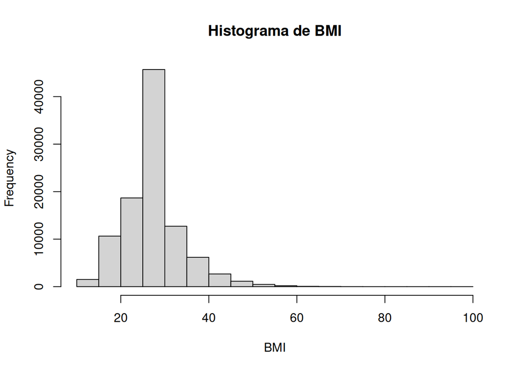

```r
# Histogrma
# Graficar histograma de 'bmi' y obtener media y varianza muestral
hist(datos$bmi, breaks = 30, main = "Histograma de BMI", xlab = "BMI")
```

```r
media_muestral <- mean(datos$bmi)
varianza_muestral <- var(datos$bmi)
sigma_mle <- sqrt(varianza_muestral)  # MLE para sigma es la raíz de la varianza muestral
cat("Media muestral:", media_muestral, "\n")
```

```
## Media muestral: 27.32077
```

```r
cat("Varianza muestral:", varianza_muestral, "\n")
```

```
## Varianza muestral: 44.04689
```

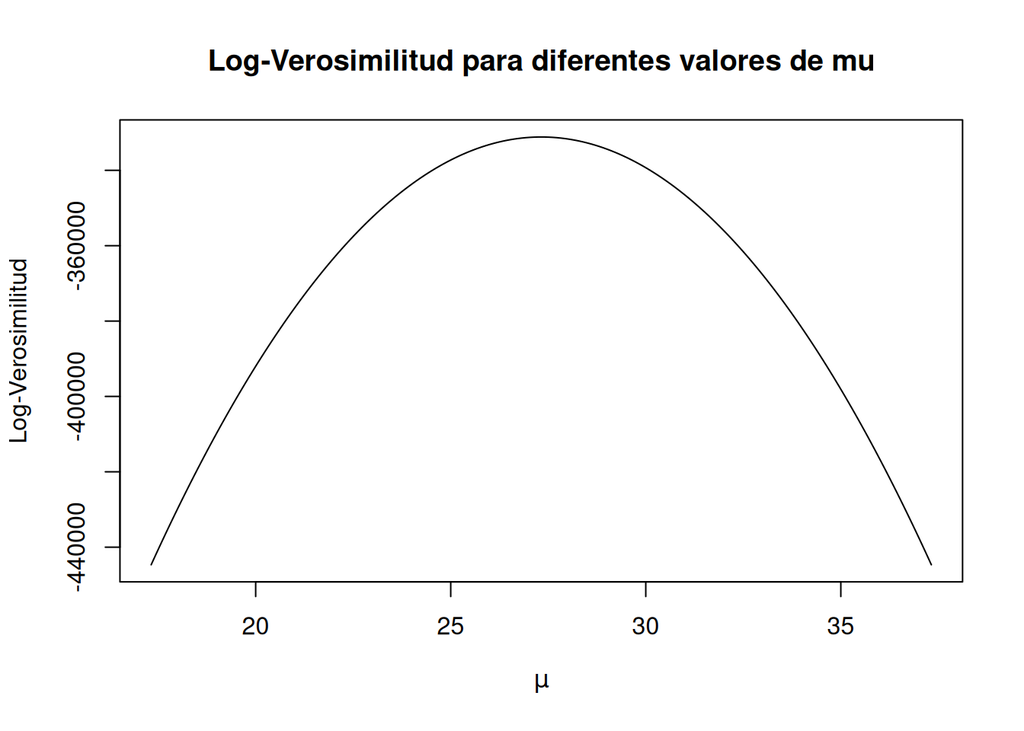

```r
# Definir la función de log-verosimilitud
loglike <- function(mu, sigma) {
  n <- length(datos$bmi)
  suma_cuadrados <- sum((datos$bmi - mu)^2)
  -(n/2) * log(2 * pi) - n * log(sigma) - (1 / (2 * sigma^2)) * suma_cuadrados
}

# Graficar la verosimilitud para diferentes valores de mu (manteniendo sigma fijo en el valor MLE)
mu_values <- seq(from = media_muestral - 10, to = media_muestral + 10, by = 0.1)
loglike_values <- sapply(mu_values, function(mu) loglike(mu, sigma_mle))

# Graficar los valores de log-verosimilitud
plot(mu_values, loglike_values, type = "l", xlab = expression(mu), ylab = "Log-Verosimilitud", main = "Log-Verosimilitud para diferentes valores de mu")
```

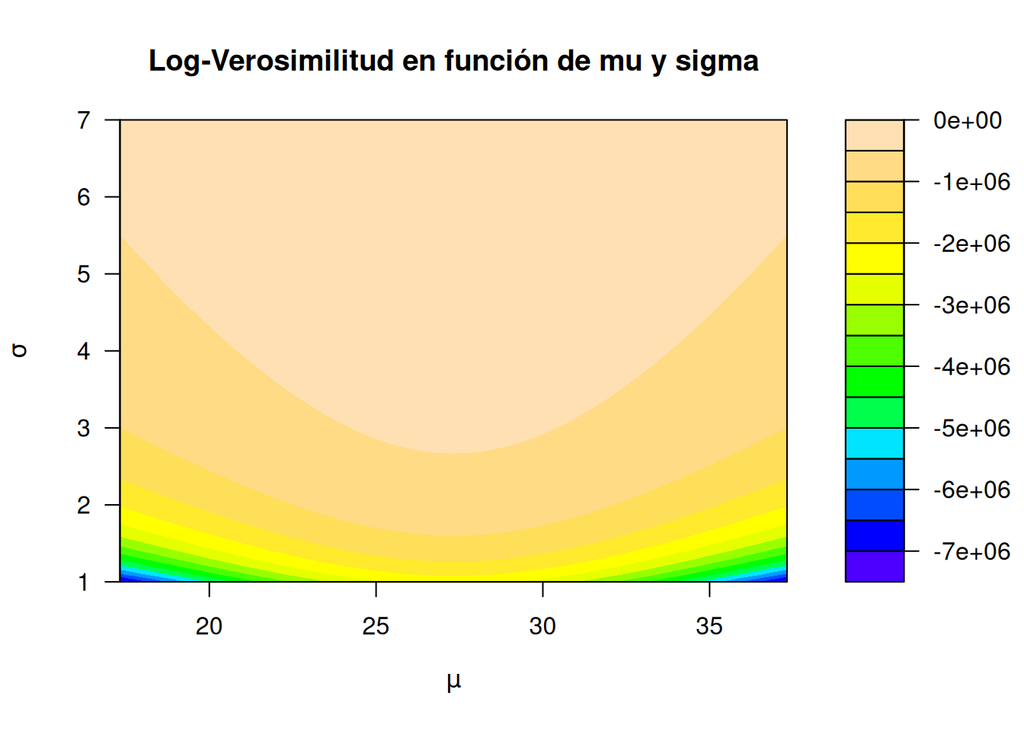

```r
# Gráfico de calor para explorar el rango de valores de mu y sigma
ll_plot <- function(mu, sigma) {
  if (sigma <= 0) return(NA)  # para evitar valores negativos de sigma
  loglike(mu, sigma)
}

ll_plot <- Vectorize(ll_plot)

# Definir rangos para mu y sigma
mu_m <- seq(from = media_muestral - 10, to = media_muestral + 10, by = 0.5)
sigma_m <- seq(from = 1, to = 7, by = 0.1)

# Calcular la verosimilitud para todos los valores de mu y sigma
likelihood_m <- outer(X = mu_m, Y = sigma_m, FUN = ll_plot)

# Graficar el gráfico de calor (contour) de la verosimilitud
filled.contour(x = mu_m, y = sigma_m, z = likelihood_m,
               xlab = expression(mu), ylab = expression(sigma),
               color = topo.colors, main = "Log-Verosimilitud en función de mu y sigma")
```

```r
# Definir la función de verosimilitud para optimización
likelihood_mean <- function(param) {
  mu <- param[1]
  sigma <- param[2]
  if (sigma <= 0) return(Inf)  # para evitar valores negativos de sigma
  -loglike(mu, sigma)  # Negativo porque optimizamos minimizando
}

# Optimizar usando nlminb()
resultado_opt <- nlminb(start = c(media_muestral, sqrt(varianza_muestral)),
                        objective = likelihood_mean,
                        lower = c(media_muestral - 10, 1),
                        upper = c(media_muestral + 10, 7))

cat("Resultado optimización (mu, sigma):", resultado_opt$par, "\n")
```

```
## Resultado optimización (mu, sigma): 27.32077 6.63675
```

```r
cat("Media teórica MLE:", media_muestral, "\n")
```

```
## Media teórica MLE: 27.32077
```

```r
cat("Resultado nlminb:", resultado_opt$par[1], "para mu y", resultado_opt$par[2], "para sigma", "\n")
```

```
## Resultado nlminb: 27.32077 para mu y 6.63675 para sigma
```

> Respuesta

La estimación de máxima verosimilitud (MLE) para la media del índice de masa corporal (BMI) se realizó utilizando los datos proporcionados. Primero, se generó un histograma de los valores de BMI, donde se observó que la mayoría de los datos están concentrados entre 20 y 35, con una cola hacia valores más altos. La media muestral calculada fue 27.32077 y la varianza muestral 44.04689. Estos resultados reflejan un valor promedio del BMI moderadamente alto, con una dispersión relativamente pequeña.

El estimador de máxima verosimilitud (MLE) de la media, bajo el supuesto de una distribución normal con la varianza fijada en el valor muestral, se obtuvo aplicando la fórmula de la log-verosimilitud. El valor teórico del MLE para la media resultó ser 27.32077, que coincide con la media muestral, lo cual es esperado dado que el MLE para la media de una distribución normal es equivalente a la media muestral.

El gráfico de la log-verosimilitud en función de diferentes valores de mu muestra una forma parabólica invertida, con un máximo en torno a mu = 27.32, confirmando que la media muestral maximiza la función de verosimilitud. Esta interpretación es correcta, ya que el punto máximo de la curva representa el valor de mu que maximiza la probabilidad de observar los datos dados.

Finalmente, se utilizó el algoritmo nlminb() para encontrar computacionalmente los valores óptimos de mu y sigma. Los resultados de la optimización fueron mu = 27.32077 y sigma = 6.63675, valores que coinciden con los resultados teóricos y empíricos previamente calculados. Esto sugiere una alta consistencia y validez en el procedimiento realizado.

### Pregunta 4: Bootstrap I

En esta pregunta se error e inetrvalo de confianza para la varianza de la columna `HbA1c_level`.

Las actividades por realizar son las siguientes:

- Programar el método Bootstrap para calcular el error estándar de la varianza. No se permite la utilización de librerías de bootstrap para esta parte.
- Visualizar a través de un de puntos las distintas varianzas obtenidas al realizar el muestreo con Bootstrap y comparar con el valor real.
- Visualizar a través de un gráfico el histograma obtenido al realizar el muestreo con Bootstrap y comparar con el valor real.
- Obtener el 95% de intervalo de confianza de la estimación.
- ¿Qué puede se inferir a pertir de los resutados de Bootstrap?

**Respuesta:**

```r
# Bootstrap
B <- 5000
largo <- length(datos$HbA1c_level)
output <- c()
```

```r
for (it in 1:B) {

  x <- datos$HbA1c_level
  samp.it <- sample(datos$HbA1c_level, largo, replace=T)
  var_muestra <- var(samp.it)
  output[it] <- var_muestra

}

# varianza real
var_real <- var(datos$HbA1c_level)

# ahora calculamos el error estandar
error_var <- sd(output)
print(error_var)
```

```
## [1] 0.005450359
```

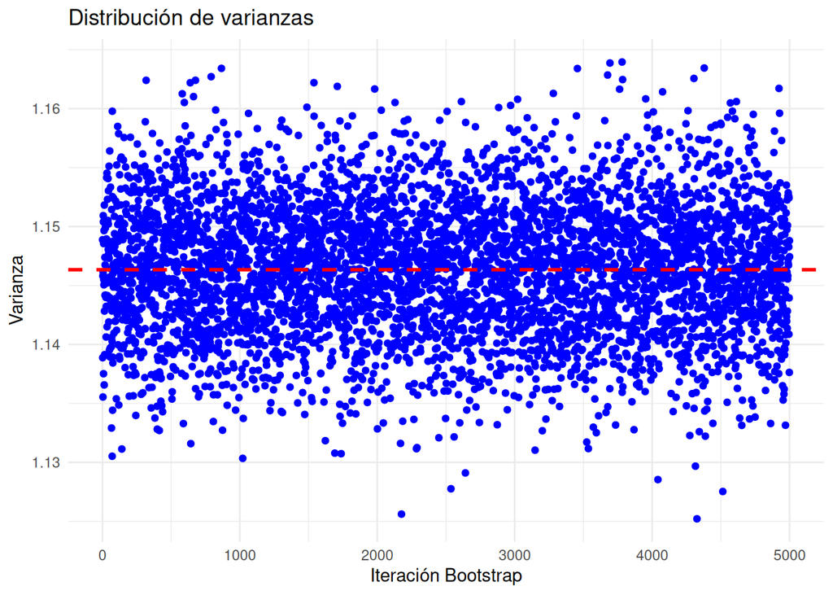

```r
# Gráfico de puntos
# dataframe para graficar los datos con ggplot
df_var <- data.frame(var_bootstrap = output)

# Gráfico de scatter plot con ggplot para las varianzas obtenidas
ggplot(df_var, aes(x = 1:length(var_bootstrap), y = var_bootstrap)) +
  geom_point(color = "blue") +
  geom_hline(aes(yintercept = var_real), color = "red", linetype = "dashed", size = 1) +
  ggtitle("Distribución de varianzas") +
  xlab("Iteración Bootstrap") +
  ylab("Varianza") +
  theme_minimal()
```

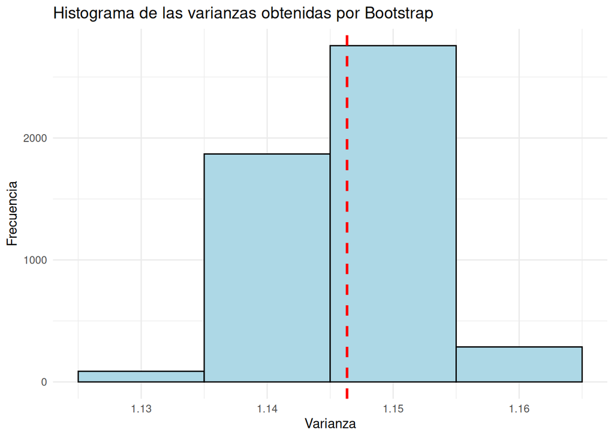

```r
# Histogrma
ggplot(df_var, aes(x = var_bootstrap)) +
  geom_histogram(binwidth = 0.01, fill = "lightblue", color = "black") +
  geom_vline(aes(xintercept = var_real), color = "red", linetype = "dashed", size = 1) +
  ggtitle("Histograma de las varianzas obtenidas por Bootstrap") +
  xlab("Varianza") +
  ylab("Frecuencia") +
  theme_minimal()
```

```r
# Obtenemos error e intervalos de confianze
se_vars <- sd(output) #error estandar de la varianza
alpha <- 0.05
z_a2 <- qnorm(1 - alpha/2) # valor critico


# límite inferios
l.CI <- quantile(output, alpha/2)
# límite superior
u.CI <- quantile(output, 1-alpha/2)

sprintf('El intervalo de confidencia de 95%% de las varianzas es: (%.3f,%.3f)', l.CI , u.CI)
```

```
## [1] "El intervalo de confidencia de 95% de las varianzas es: (1.136,1.157)"
```

```r
sprintf('El SE de la varianzas es: (%.3f)', se_vars)
```

```
## [1] "El SE de la varianzas es: (0.005)"
```

> Respuesta:

> A partir de los resultados, se puede observar que en el grafico de las distribuciones de las varianzas se muestra una dispersion densa y estable a lo largo de las iteraciones (rango entre 1.12 y 1.16). La media de las varianzas obtenidas es de aproximadamente 1.15, por lo que no parece haber una gran variacion de las varianzas, lo que sugiere que el estimador es estable. En el histograma se observa una distribucion en donde los datos estan agrupados en torno a un valor central (1.14 y 1.15), con muy pocas iteraciones por encima de 1.16 y bajo 1.13. La marca media de las varianzas indica que esta muy cerca del centro de la distribucion (linea roja).

> Los intervalos de confianza del 95% son 1.136 y 1.157, con un error estandar de 0.005, lo cual es bajo por lo que las varianzas obtenidas con el metodo Boostrap estan concentradas entorno al valor promedio. En resumen, al obtener un error estandar bajo indica que el modelo se ajusto bien a los datos, y ademas la varianza de las estimaciones es pequeña, por lo que hay calidad en el ajuste.

### Pregunta 5: Bootstrap II

El siguiente código genera una regresión lineal de `bmi` con respecto a `age`, es decir, una función lineal de `age`, $y(age) = b + m\cdot age$, que pretende determinar el valor de `bmi`.

```r
linearMod <- lm(bmi ~ age, data=datos)
print(linearMod)
```

```
##
## Call:
## lm(formula = bmi ~ age, data = datos)
##
## Coefficients:
## (Intercept)          age
##    23.15536      0.09945
```

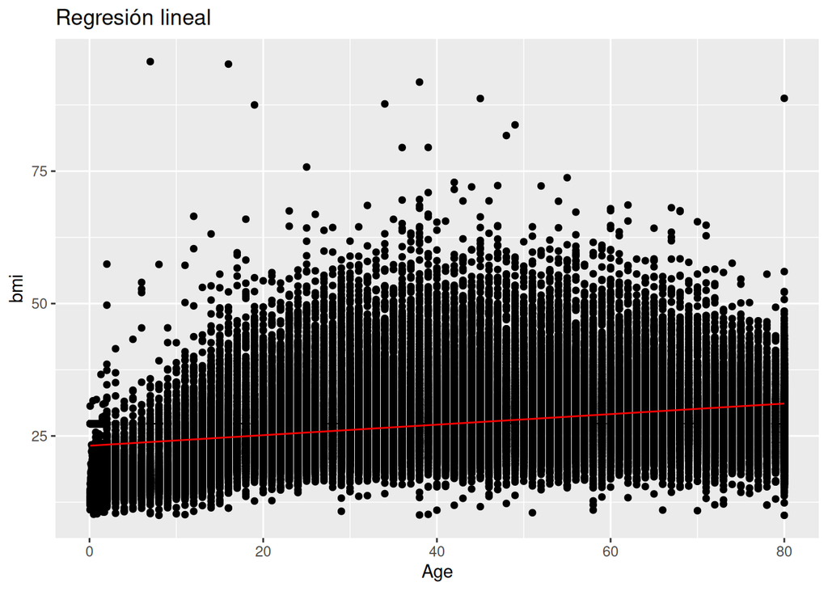

```r
m <- linearMod$coefficients["age"]
b <- linearMod$coefficients["(Intercept)"]

ggplot() +
  geom_point(aes(x=datos$age, y=datos$bmi)) +
  geom_line(aes(x=datos$age, y=datos$age*m+b), color="red") +
  ggtitle("Regresión lineal") +
  ylab("bmi") +
  xlab("Age")
```

Repita el proceso de la pregunta 4 para estimar el error e intervalos de confianza de los parámetros de la regresión ($m$ y $b$). ¿Qué indican los resultados de Bootstrap?¿Un valor bajo en el error significa que la regresión es buena?

```r
# Bootstrap
B <- 500
largo <- 1000
output_m <- c()
output_b <- c()

for (it in 1:B) {

  # muestra aleatoria
  muestra_indices <- sample(1:largo, largo, replace=T)
  muestra <- datos[muestra_indices, ]

  # Ajustamos el modelo lineal a la muestra
  linearMod_bootstrap <- lm(bmi ~ age, data = muestra)

  # Almacenamos los coeficientes
  output_m[it] <- linearMod_bootstrap$coefficients["age"]
  output_b[it] <- linearMod_bootstrap$coefficients["(Intercept)"]

}

# ahora calculamos el error estandar
error_m <- sd(output_m)
error_b <- sd(output_b)
sprintf('Error estandar de m: (%.3f)', error_m)
```

```
## [1] "Error estandar de m: (0.009)"
```

```r
sprintf('Error estandar de b: (%.3f)', error_b)
```

```
## [1] "Error estandar de b: (0.414)"
```

```r
# Obtenemos error e intervalos de confianze
se_m <- sd(output_m)
alpha <- 0.05
z_a2 <- qnorm(1 - alpha / 2)

# límite inferios
l.CI <- quantile(output_m, alpha/2)
# límite superior
u.CI <- quantile(output_m, 1-alpha/2)

sprintf('El intervalo de confidencia de 95%% de las varianzas es: (%.3f,%.3f)', l.CI , u.CI)
```

```
## [1] "El intervalo de confidencia de 95% de las varianzas es: (0.078,0.116)"
```

```r
sprintf('El SE de la varianzas es: (%.3f)', se_m)
```

```
## [1] "El SE de la varianzas es: (0.009)"
```

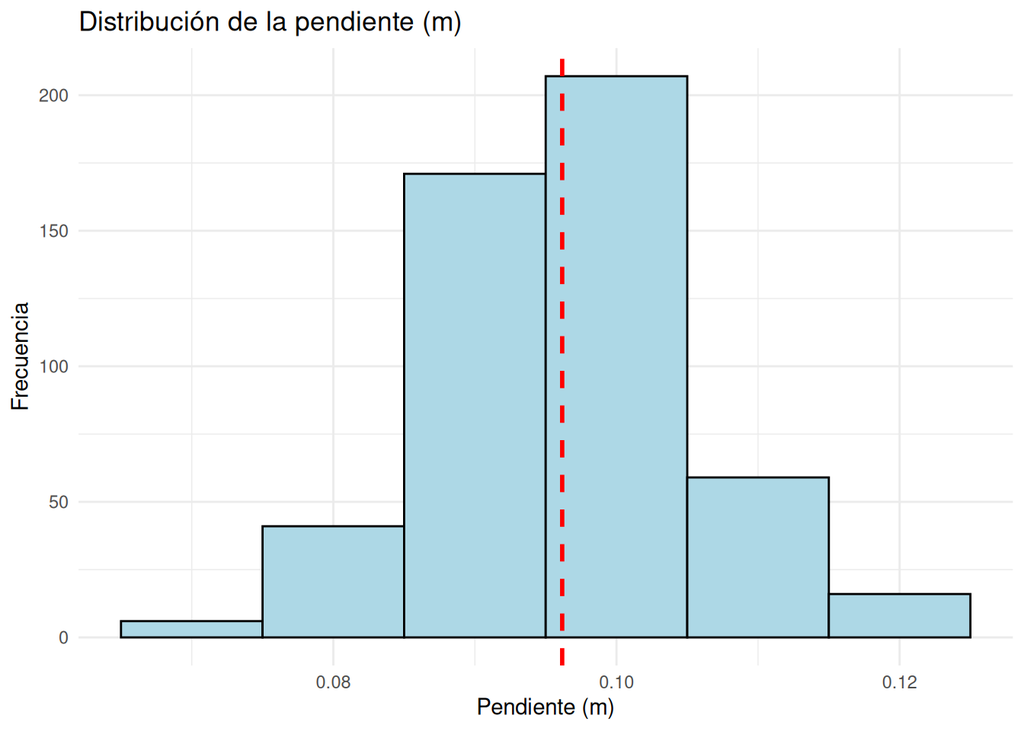

```r
df_m <- data.frame(m_bootstrap = output_m)

ggplot(df_m, aes(x = m_bootstrap)) +
  geom_histogram(binwidth = 0.01, fill = "lightblue", color = "black") +
  geom_vline(aes(xintercept = mean(output_m)), color = "red", linetype = "dashed", size = 1) +
  ggtitle("Distribución de la pendiente (m)") +
  xlab("Pendiente (m)") +
  ylab("Frecuencia") +
  theme_minimal()
```

```r
# Obtenemos error e intervalos de confianze
se_b <- sd(output_b)
alpha <- 0.05
z_a2 <- qnorm(1 - alpha / 2)

# límite inferios
l.CI <- quantile(output_b, alpha/2)
# límite superior
u.CI <- quantile(output_b, 1-alpha/2)

sprintf('El intervalo de confidencia de 95%% de los sesgos es: (%.3f,%.3f)', l.CI , u.CI)
```

```
## [1] "El intervalo de confidencia de 95% de los sesgos es: (22.238,23.851)"
```

```r
sprintf('El SE del sesgo es: (%.3f)', se_b)
```

```
## [1] "El SE del sesgo es: (0.414)"
```

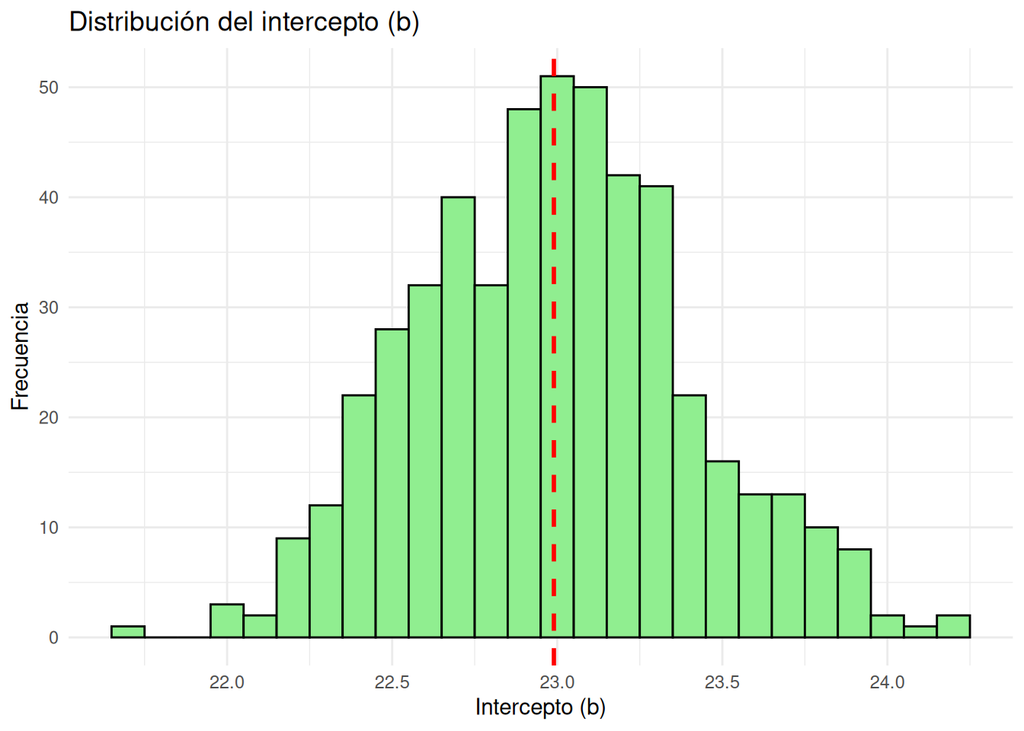

```r
df_b <- data.frame(b_bootstrap = output_b)

ggplot(df_b, aes(x = b_bootstrap)) +
  geom_histogram(binwidth = 0.1, fill = "lightgreen", color = "black") +
  geom_vline(aes(xintercept = mean(output_b)), color = "red", linetype = "dashed", size = 1) +
  ggtitle("Distribución del intercepto (b)") +
  xlab("Intercepto (b)") +
  ylab("Frecuencia") +
  theme_minimal()
```

> Respuesta:

> Al tener una pendiente pequeña (0.099 aprox) puede significar que la relacion entre age y bmi es debil, lo que indica que aunque la regresion sea estadisticamente significativa, la influencia sobre la edad sobre el bmi es pequeña.

> En resumen, el modelo es estable en terminos del error estandar, pero el valor bajo de la pendiente sugiere que las variables no tienen impactos significativos sobre eloos. Para ver si la regresion es buena habria que revisar el coeficiente de determinacion (R**2)

A work by CC6104